# Paper Consumption at ETH Zurich

Capstone Project

Author

Affiliation

Ella Haechler

[ETH Zurich](https://ethz.ch/de.html)

Published

June 5, 2025

Abstract

This survey is about the research question on how the consumption of paper changes between Bachelor and Master students at ETH.

# Introduction

In recent years, sustainability and resource management have gained importance. Large institutions, including universities, are seeking ways to contribute to a more environmentally friendly future and are actively pursuing new strategies for improvement (Matthews, 2023). Among the various challenges they face, paper consumption stands out as an area with considerable potential for positive change (Obrist, 2022).

An anonymous survey examined the paper usage habits of ETH students. The study’s goal was to investigate the differences in paper consumption between bachelor and master students at ETH. The analysis of these usage patterns will help to develop future strategies that promote a more responsible use of resources at universities (Henderson et al., 2015).

# Methods

# Results

In the following Table 1 an overview about the basic information collected in the survey is given. Not only did bachelor students consume more paper on average than master students, but their consumption also varied more, as reflected in the higher standard deviation and a significantly higher median. In contrast, master students exhibited both lower average consumption and lower variability. These results suggest that paper consumption tends to decrease and become more constant during the transition from bachelor to master studies.

```r
paper |>
  group_by(degree) |>
  summarise(
    Mean = mean(printing_amount, na.rm = TRUE),
    sd = sd(printing_amount, na.rm = TRUE),
    Median = median(printing_amount, na.rm = TRUE),
    Min = min(printing_amount, na.rm = TRUE),
    Max = max(printing_amount, na.rm = TRUE),
    n = n(),
    page_usage_per_person = round(Mean / n, digits = 2)
    ) |>
  ungroup() %>%
  gt() |>
  tab_header(title = "Printing habits of bachelor and master students") %>%
  fmt_number(columns = c(Mean, sd, Median, Min, Max),
             decimals = 0) |>
  tab_style(
    style = cell_text(weight = "bold"),
    locations = cells_column_labels(everything())
  )
```

Table 1: Printing habits of bachelor and master students

Printing habits of bachelor and master students

| degree | Mean | sd | Median | Min | Max | n | page_usage_per_person |
| --- | --- | --- | --- | --- | --- | --- | --- |
| bachelor | 299 | 179 | 450 | 5 | 500 | 77 | 3.88 |
| master | 112 | 98 | 76 | 5 | 350 | 48 | 2.33 |

Figure 1 displays the distribution of printing locations among bachelor students, with bars representing the count of students for each location, differentiated by their printing decision. The most frequently selected printing location was the university, while other locations such as the copy shop or home were chosen less often. Figure 2 demonstrated the same information for master students. The university is also the most chosen location for printing, where at work is not even displayed and therefore is not a commonly used place to print. The plot also shows the variation in printing decisions (as indicated by the color fill) across different locations. These results provide a clear overview of where bachelor students most commonly print and how their printing decisions vary by location.

Both degree levels most frequently based their printing decision on factors such as convenience or environmental aspects. This pattern suggests that these two considerations significantly influenced the printing behavior of the surveyed population. Cost also plays a role, but is not as significant as expected. It’s also interesting to note that bachelor’s students print while working, whereas master’s students do not. One might expect the opposite, given that master’s students have a higher workload than bachelor’s students. One reason for this could be that bachelor’s students print more pages overall.Further conclusions cannot be drawn due to a lack of information such as explanations for the printing decision none and other.

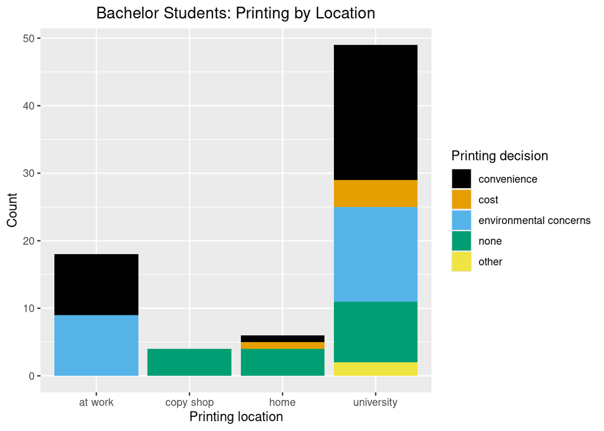

Figure 1: Relationship between printing decisions and location choice of bachelor students

```r
ggplot(data = filter(paper, degree == "bachelor"),
       mapping = aes(x = printing_location,
                     fill = printing_decision)) +
  geom_bar() +
  labs(title = "Bachelor Students: Printing by Location",
       x = "Printing location",
       y = "Count",
       fill = "Printing decision") +
  scale_fill_colorblind() +
  theme(plot.title = element_text(hjust = 0.5))

# Create the filtered data frame
paper_decision_location_bachelor_df <- paper %>%
  filter(degree == "bachelor")

# Save the data frame to CSV
write_csv(paper_decision_location_bachelor_df, here::here("data/final/fig-decision-location-bachelor.csv"))
```

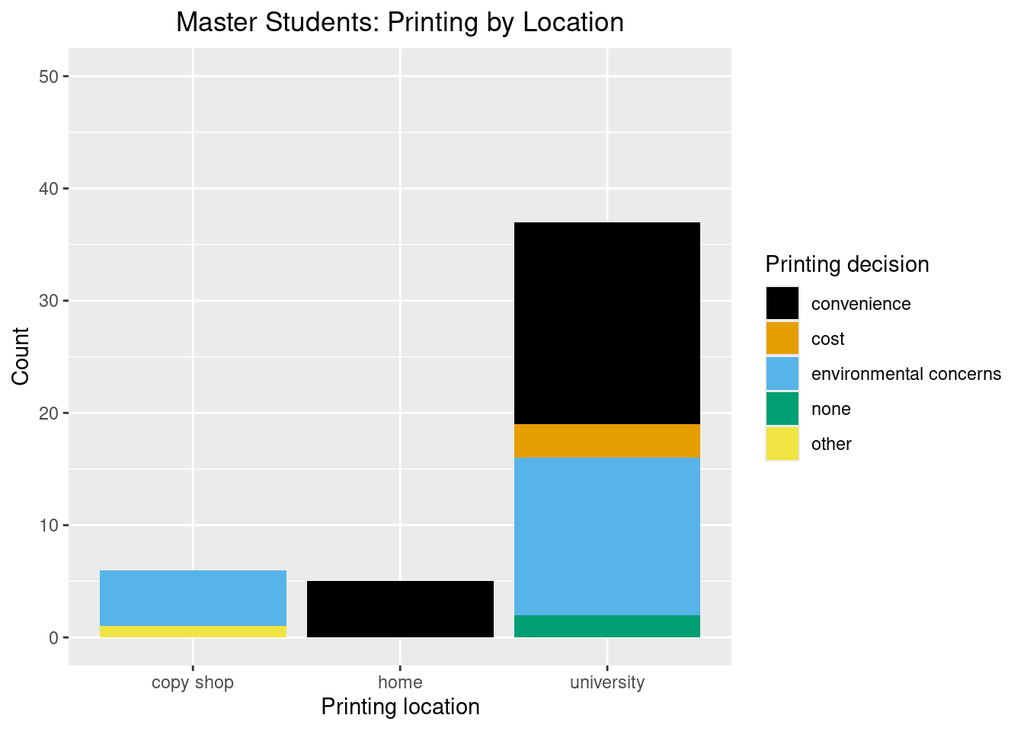

Figure 2: Relationship between printing decisions and location choice of master students

```r
ggplot(data = filter(paper, degree == "master"),
       mapping = aes(x = printing_location,
                     fill = printing_decision)) +
  geom_bar() +
  labs(title = "Master Students: Printing by Location",
       x = "Printing location",
       y = "Count",
       fill = "Printing decision") +
  scale_fill_colorblind() +
  coord_cartesian(ylim = c(0, 50)) +
  theme(plot.title = element_text(hjust = 0.5))

# Create the filtered data frame
paper_decision_location_master_df <- paper %>%
  filter(degree == "master")

# Save the data frame to CSV
write_csv(paper_decision_location_master_df, here::here("data/final/fig-decision-location-master.csv"))
```

Figure 3 shows the relationship between age and the number of pages printed among engineering students, with data points differentiated by degree level. The graph highlights the variability in print volume between age groups and between undergraduate and graduate students. Master’s students, who are also generally older, print fewer documents than undergraduate students. This trend could also be influenced by other factors, such as a reduced number of required courses or changes in the academic workload during the master’s program. Among undergraduate students, a trend toward less printing with increasing age is evident. However, no clear linear trend is evident, suggesting that age alone is not a strong predictor of paper consumption in this group.

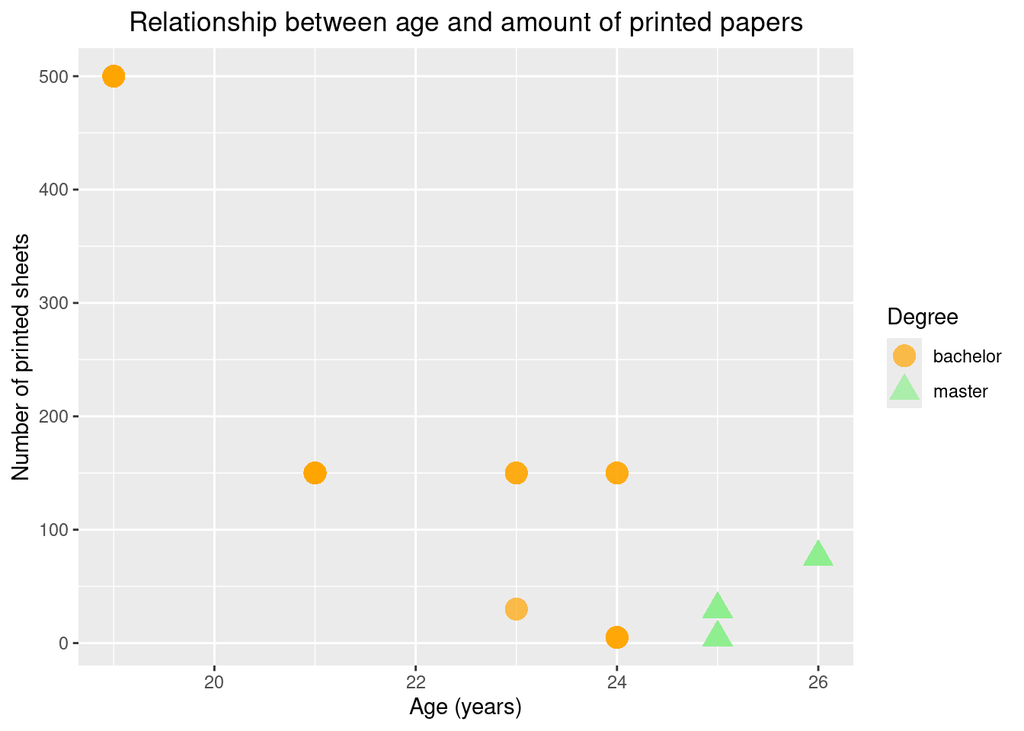

Figure 3: Relationship between age and amount of printed papers

```r
ggplot(data = filter(paper, course == "Engineering"),
       mapping = aes(x = age,
                     y = printing_amount,
                     color = degree,
                     shape = degree)) +
  geom_point(size = 5, alpha = 0.7) +
  scale_color_manual(values = c("orange", "lightgreen", "grey")) +
  labs(title = "Relationship between age and amount of printed papers",
       x = "Age (years)",
       y = "Number of printed sheets",
       color = "Degree",
       shape = "Degree") +
  theme(plot.title = element_text(hjust = 0.5))


# Create the filtered data frame
paper_course <- paper %>%
  filter(course == "Engineer")

# Save the data frame to CSV
write_csv(paper_course, here::here("data/final/fig-course-paper-consumption.csv"))
```

# Conclusions

- Survey results show that bachelor students use more paper and display greater variability in their printing habits compared to master students.
- Paper consumption tends to decrease and become more consistent as students progress from bachelor to master studies, possibly due to changes in academic workload and course requirements.
- The university is the most common printing location for both groups.
- Both bachelor’s and master’s students primarily base their printing decisions on convenience and environmental considerations, with cost playing a secondary role.
- No strong correlation was found between age and paper usage, suggesting that factors other than age, such as degree level and individual preferences, are more influential in determining printing behavior.
- Further research with a larger and more diverse sample could provide deeper insights into the motivations behind students’ printing decisions and inform more effective sustainability initiatives.

## References

Henderson, M., Selwyn, Finger, & and Aston, R. (2015). Students’ everyday engagement with digital technology in university: Exploring patterns of use and “usefulness.” *Journal of Higher Education Policy and Management*, *37*(3), 308–319. https://doi.org/10.1080/1360080X.2015.1034424

Matthews, J. K. (2023). Preferring print: The planned behavior and preferences of first-generation college students in the academic library. *The Journal of Academic Librarianship*, *49*(6), 102813. https://doi.org/10.1016/j.acalib.2023.102813

Obrist, M. D. (2022). Long-term energy efficiency and decarbonization trajectories for the Swiss pulp and paper industry. *Sustainable Energy Technologies and Assessments*, *52*, 101937. https://doi.org/10.1016/j.seta.2021.101937